# CT genes analysis in germ cells

```r
library("tidyverse")
library("CTexploreR")
library("ComplexHeatmap")
library("circlize")
library("SummarizedExperiment")
library("flextable")

set_flextable_defaults(
font.family = "Arial", font.size = 10,
border.color = "black",
padding = 6,
background.color = "#EFEFEF",
big.mark = "")
```

```r
all_genes_types <- all_genes %>%
  dplyr::rename(gene = external_gene_name) %>%
  mutate(Regulation = case_when(regulated_by_methylation ~ "Methylation",
                                !regulated_by_methylation ~ "Not methylation")) %>%
  mutate(Chr = case_when(X_linked ~ "X-linked",
                         !X_linked ~ "not X")) %>%
  mutate(chromosome = case_when(chr == "X" ~ "X-linked",
                                chr == "Y" ~ "Y-linked",
                                !chr %in% c("X", "Y") ~ "Autosome")) %>%
  mutate(chr_met = case_when(regulated_by_methylation & X_linked ~ "X_met",
                             !regulated_by_methylation & X_linked ~ "X_not_met",
                             regulated_by_methylation & !X_linked ~ "not_X_met",
                             !regulated_by_methylation & !X_linked ~ "not_X_not_met")) %>%
  mutate(GTEX_specificity = case_when(GTEX_category == "testis_specific" ~ "Testis specific",
                                        GTEX_category == "testis_preferential" ~ "Testis preferential",
                                        GTEX_category == "lowly_expressed" ~ "Undetectable in GTEX")) %>%
  mutate(testis_specificity = case_when(testis_specificity == "testis_specific" ~ "Testis specific",
                                        testis_specificity == "testis_preferential" ~ "Testis preferential")) %>%
  mutate(testis_specificity = factor(testis_specificity, levels = c("Testis specific", "Testis preferential"))) %>%
  mutate(chr_met = factor(chr_met,
                          levels = c("X_met", "not_X_met", "X_not_met", "not_X_not_met"))) %>%
  mutate(met_3_groups = case_when(regulated_by_methylation & X_linked ~ "Methylation X-linked",
                                   regulated_by_methylation & !X_linked ~ "Methylation not X-linked",
                             !regulated_by_methylation ~ "Not Methylation")) %>%
  mutate(met_3_groups = factor(met_3_groups,
                          levels = c("Methylation X-linked", "Methylation not X-linked", "Not Methylation")))

CT_genes_types <- all_genes_types %>%
  filter(CT_gene_type == "CT_gene")

CT_genes <- CT_genes %>%
  filter(CT_gene_type == "CT_gene")
```

```r
legends_param <- list(
  labels_gp = gpar(col = "black", fontsize = 4),
  title_gp = gpar(col = "black", fontsize = 5, fontface = "bold"),
  simple_anno_size = unit(0.2, "cm"),
  row_names_gp = gpar(fontsize = 3),
  annotation_name_side = "left",
  border = FALSE,
  border_gp = gpar(lwd = 0.2),
  grid_width = unit(0.2, "cm"),
  grid_height = unit(0.05, "cm"),
  legend_height = unit(1, "cm"),
  use_raster = TRUE,
               raster_device = "CairoPNG",
               raster_quality = 10)

legend_colors <- c("#5E4FA2", "#3288BD", "#66C2A5", "#ABDDA4", "#E6F598",
"#FFFFBF", "#FEE08B", "#FDAE61", "#F46D43", "#D53E4F",
"#9E0142")

TCGA_colors <- c(
"BRCA" = "midnightblue", "COAD" = "darkorchid2",
"ESCA" = "gold", "HNSC" = "deeppink2",
"LUAD" = "seagreen", "LUSC" = "seagreen3",
"SKCM" = "red3")

CCLE_colors <- c(
"Lung" = "seagreen3", "Skin" = "red3",
"Bile_Duct" = "mediumpurple1", "Bladder" = "mistyrose2",
"Colorectal" = "plum", "Lymphoma" = "steelblue1",
"Uterine" = "darkorange4", "Myeloma" = "turquoise3",
"Kidney" = "thistle4",
"Pancreatic" = "darkmagenta", "Brain" = "palegreen2",
"Gastric" = "wheat3", "Breast" = "midnightblue",
"Bone" = "sienna1", "Head_and_Neck" = "deeppink2",
"Ovarian" = "tan3", "Sarcoma" = "lightcoral",
"Leukemia" = "steelblue4", "Esophageal" = "khaki",
"Neuroblastoma" = "olivedrab1")

DAC_colors <- c(
"B2-1" = "olivedrab2", "HCT116" = "lightcoral",
"HEK293T" = "seagreen3", "HMLER" = "mediumpurple1",
"IMR5-75" = "deeppink2", "NCH1681" = "steelblue2",
"NCH612" = "red3", "TS603" = "darkmagenta")

DAC_treatment_colors <- c("CTL" = "royalblue4", "5-aza" = "maroon3")

Regulation_colors <- c("Methylation" = "indianred2",
"Not methylation"= "cyan4")

chr_met_colors = c("X_met" = "mediumorchid2",
"X_not_met" = "mediumseagreen",
"not_X_met"= "darkorange1",
"not_X_not_met" = "dodgerblue1")

Chr_colors = c("X-linked" = "deeppink3", "not X" = "lightgreen")
Chr_colors_with_Y = c("X-linked" = "deeppink3", "Autosome" = "lightgreen", "Y-linked" = "black")

GTEX_specificity_colors = c("Testis specific" = "green",
                              "Testis preferential" = "purple",
                              "Undetectable in GTEX" = "gray")

Testis_specificity_colors = c("Testis specific" = "mediumpurple2",
"Testis preferential" = "goldenrod1",
"Undetectable in GTEX" = "gray")

# Testis_specificity_colors = c("Testis specific" = "green",
#                               "Testis preferential" = "purple")

testis_colors <- c(
  "Spermatogonial stem cells" = "floralwhite", "Spermatogonia" = "moccasin",
  "Early spermatocyte" = "gold",
  "Late spermatocyte" = "orange",
  "Round spermatid" = "red2",
  "Elongated spermatid" = "darkred", "Sperm" = "purple")

Fetal_cell_colors = c("Primordial germ Cells" = "lightblue1",
                      "Primordial germ Cells (F)" = "pink",
                      "Fetal germ cells (F)" = "pink3",
                      "Oogonia" = "palevioletred3",
                      "Oocytes" = "mediumorchid4",
                      "Primordial germ Cells" = "lightblue1",
                      "Primordial germ Cells (M)" = "lightblue1",
                      "Fetal germ cells" = "steelblue3",
                      "Fetal germ cells (M)" = "steelblue3",
                      "Pre-spermatogonia" = "blue",
                      "soma (F)" = "gray",
                      "soma (M)" = "gray30")


Fetal_cellType_colors = c(
                      "Mitotic FGC (F)" = "pink3",
                      "Meiotic FGC (F)" = "palevioletred3",
                      "Oogenesis FGC (F)" = "mediumorchid4",
                      "Mitotic FGC (M)" = "steelblue3",
                      "Mitotic arrested (M)" = "blue",
                      "soma (F)" = "gray",
                      "soma (M)" = "gray30")

oocytes_colors <- c("Growing oocytes" = "mediumpurple1",
"Fully grown oocytes" ="lightgreen",
"Metaphase I" = "mediumvioletred",
"Metaphase II" = "mediumpurple4")

sex_colors <- c("F" = "deeppink", "M"= "steelblue")

stage_colors <- c( "pre-meiotic" = "peachpuff",
"meiotic"= "lightsalmon",
"post-meiotic" = "maroon4",
"somatic" = "gray")

Stage_colors <- c( "Fetal" = "lightgreen",
"Adult"= "steelblue")


MethDep_colors <- c("MethDep" = "indianred2",
"Non-MethDep"= "cyan4")

CT_group_colors = c("X-linked MethDep" = "indianred2",
                    "Not X MethDep" = "darksalmon",
                  "Non-MethDep" =   "cyan4")
```

# Fig6A and 7A: Heatmaps

```r
testis_sce <- CTdata::testis_sce()

testis_sce <- testis_sce[CT_genes$external_gene_name[
  CT_genes$external_gene_name %in% rownames(testis_sce)],]

missing <- CT_genes$external_gene_name[
  !CT_genes$external_gene_name %in% rownames(testis_sce)]
```

- 34 genes not detected at all in adult testis scRNAseq:

KAZN-AS1, NFIA-AS1, LRRC52-AS1, ZC3H11B, THORLNC, LINC02377, SLC7A11-AS1, LINC02241, LINC02228, LINC03004, SEC61G-DT, ZNF722, GTF2I-AS1, SPATA31C2, TEX48, LINC02663, LINC02750, FAM230C, GOLGA6L7, LINC02864, ZNF723, PPP4R3C, CENPVL2, CENPVL1, CT47A1, CT45A6, CT45A7, CT45A8, CT45A9, MAGEA4-AS1, MAGEA2, VCY, VCY1B, RBMY1B

```r
# pool Sperm1 and Sperm2 types
levels(testis_sce$type)[c(7,8)] <- "Sperm"
germcells <-  c("SSC", "Spermatogonia", "Early_spermatocyte",
                "Late_spermatocyte", "Round_spermatid",
                "Elongated_spermatid", "Sperm")

testis_sce <- testis_sce[, testis_sce$type %in% germcells]
testis_sce$type <- factor(testis_sce$type, levels = germcells)


# Keep genes detected in at least x % of germ cells
# ! Each cell type is present at different proportion
# (much more sperm cells than SSC cells for instance)
# table(testis_sce$type)
# => Calculate for each gene the proportion of expressing cells
# (> testis_logcount_thr) and keep genes expressed in at least x% of a cell type
# instead of just keeping genes expressed in at least x% of cells.
testis_percent_thr <- 0.05
testis_logcount_thr <- 0

percent_of_expressing_cells <-
  tibble(gene = rownames(testis_sce),
         prop = rowSums(assay(testis_sce[, testis_sce$type %in% germcells[1]],
                              "logcounts") > testis_logcount_thr) /
           dim(testis_sce[, testis_sce$type %in% germcells[1]])[2])
names(percent_of_expressing_cells) <- c("gene", germcells[1])

for (cell in germcells[-1]) {
  tmp <-
    tibble(gene = rownames(testis_sce),
           prop = rowSums(assay(testis_sce[, testis_sce$type %in% cell],
                                           "logcounts") > testis_logcount_thr) /
             dim(testis_sce[, testis_sce$type %in% cell])[2])
  names(tmp) <- c("gene", cell)
  percent_of_expressing_cells <- left_join(percent_of_expressing_cells, tmp)
}

kept_genes <- rownames(testis_sce)[rowSums(percent_of_expressing_cells[,-1] > testis_percent_thr) > 0]
```

- 96 genes are detected in at least 5% of a specific testis cell type
- Genes removed (detected in less than 5% of cells):

GFY, CXorf49, CXorf49B, NXF2, CT47A12, CT47A11, CT45A3, CT45A5, MAGEA9, CTAG1A, CTAG1B, TSPY4, TSPY1, TSPY9, RBMY1A1, RBMY1E

```r
testis_sce <- testis_sce[kept_genes,]
```

```r
FGC_sce <- CTdata::FGC_sce()
FGC_sce <- FGC_sce[, FGC_sce$low_ncounts == "False"]
FGC_sce <- FGC_sce[, FGC_sce$high_mito == "False"]
# add missing CT genes (not in the downloaded dataset, as not detected (below detection) => were removed)
# Add zero count values for these genes
rowData(FGC_sce) <- NULL

levels(FGC_sce$type) <-
    c("Primordial germ Cells (F)", "Fetal germ cells (F)", "Oogonia", "Oocytes",
      "Primordial germ Cells (M)", "Fetal germ cells (M)", "Pre-spermatogonia")

FGC_sce <- FGC_sce[rownames(testis_sce)[rownames(testis_sce) %in% rownames(FGC_sce)],]
```

Genes detected in adult testis scRNAseq but not in fetal gonads scRNAseq:

```r
missing_CT <- rownames(testis_sce)[!rownames(testis_sce) %in% rownames(FGC_sce)]
missing_CT
```

```
## character(0)
```

```r
if (length(missing_CT) > 0) {
  print("added zero values to these genes in fetal scRNAseq")
  print(missing_CT)
  sce_missing_CT <- FGC_sce[1:length(missing_CT),]
  rownames(sce_missing_CT) <- missing_CT
  count_mat_missing_CT <- matrix(nrow = length(missing_CT), ncol = ncol(FGC_sce), data = 0)
  rownames(count_mat_missing_CT) <- missing_CT
  colnames(count_mat_missing_CT) <- colnames(FGC_sce)
  assay(sce_missing_CT,1) <- count_mat_missing_CT
  assay(sce_missing_CT,2) <- count_mat_missing_CT
  FGC_sce <- rbind(FGC_sce, sce_missing_CT)
}
```

- Genes not detected in adult oocytes dataset:

```r
oocytes_sce <- CTdata::oocytes_sce()

# add missing CT genes (not in the downloaded dataset, as not detected (below detection) => were removed)
# Add zero count values for these genes
rowData(oocytes_sce) <- NULL
oocytes_sce <- oocytes_sce[, oocytes_sce$type %in% c("Growing oocytes",
  "Fully grown oocytes",
  "Metaphase I",
  "Metaphase II")]
oocytes_sce$type <- factor(oocytes_sce$type, levels = c("Growing oocytes",
                                                        "Fully grown oocytes",
                                                        "Metaphase I",
                                                        "Metaphase II"))

oocytes_sce <- oocytes_sce[rownames(testis_sce)[
  rownames(testis_sce) %in% rownames(oocytes_sce)], ]

missing_CT <- rownames(testis_sce)[
  !rownames(testis_sce) %in% rownames(oocytes_sce)]
```

CBY2, GARIN2, CDRT15, CHCT1, XAGE1A, TEX13C

```r
if (length(missing_CT) > 0) {
  print("added zero values to these genes in oocytes scRNAseq")
  print(missing_CT)
  sce_missing_CT <- oocytes_sce[1:length(missing_CT),]
rownames(sce_missing_CT) <- missing_CT
count_mat_missing_CT <- matrix(nrow = length(missing_CT), ncol = ncol(oocytes_sce), data = 0)
rownames(count_mat_missing_CT) <- missing_CT
colnames(count_mat_missing_CT) <- colnames(oocytes_sce)
assay(sce_missing_CT,1) <- count_mat_missing_CT
assay(sce_missing_CT,2) <- count_mat_missing_CT
oocytes_sce <- rbind(oocytes_sce, sce_missing_CT)
}
```

```
## [1] "added zero values to these genes in oocytes scRNAseq"
## [1] "CBY2"   "GARIN2" "CDRT15" "CHCT1"  "XAGE1A" "TEX13C"
```

```r
legends_param <- list(
  labels_gp = gpar(col = "black", fontsize = 5),
  title_gp = gpar(col = "black", fontsize = 5),
  simple_anno_size = unit(0.2,"cm"),
  row_names_gp = gpar(fontsize = 1),
  annotation_name_side = "left",
  border = FALSE,
  border_gp = gpar(lwd = 0.01),
  grid_width = unit(0.2, "cm"),
  grid_height = unit(0.2, "cm"),
  legend_height = unit(0.2, "cm"),
  annotation_name_gp = gpar(fontsize = 0))
```

Kept 96 CT genes for the analysis.

```r
#######################################################################
# Function to downsample cell types
#######################################################################
sample_cells <- function(barcodes, nmax){
  sample(barcodes, size = min(nmax, length(barcodes)), replace = FALSE)
}
```

```r
#######################################################################
## Function to draw expression in FGC with specific annotations
## and down-sampling the number of cells from each cell type
#######################################################################
draw_FGC_heatmap <- function(genes,
                             ncells_max = NULL,
                             scale_lims = NULL,
                             title_fs = 6,
                             sex = c("F", "M"),
                             clusterRow = FALSE,
                             font_size = 6,
                             show_legend = TRUE,
                             h_width = 5,
                             h_height = 10,
                             column_name_rot = 90){

  fetal_sce <- FGC_sce
  fetal_sce$Stage <- "Fetal"

  # Set the colors used in the final heatmap based on all samples (F + M),
  # even when representing only F or M samples on the heatmap
  # => same scale of colors
  mat <-  as.matrix(assay(fetal_sce, "logcounts")[genes, ])

  if (is.null(scale_lims)) {
    scale_lims <- c(0, quantile(rowMaxs(mat), 0.8))
  }

  heatmap_colors <- colorRamp2(
    seq(scale_lims[1], scale_lims[2], length = 11),
    legend_colors)

  fetal_sce <- fetal_sce[, fetal_sce$sex %in% sex]

  df_col_FCS <- data.frame(development_stage = fetal_sce$development_stage,
                           sex = fetal_sce$sex,
                           stage = fetal_sce$stage,
                           donor_id = fetal_sce$donor_id,
                           fetal_cell_type = fetal_sce$cell_type,
                           fetal_celltype = fetal_sce$celltype,
                           type = fetal_sce$type,
                           time = fetal_sce$PCW,
                           Stage = fetal_sce$Stage)

  rownames(df_col_FCS) <- colnames(fetal_sce)
  df_col_FCS$type <- factor(df_col_FCS$type)
  if (all(sex == "M")) levels(df_col_FCS$type) <- c("PGC", "FGC", "Pre-\nSpg")
  if (all(sex == "F")) levels(df_col_FCS$type) <- c("PGC", "FGC", "Oogonia", "Oocytes")

  #Randomly pick ncells_max cells of each cell type
  if (!is.null(ncells_max)) {
    set.seed(123)
    selected_cells <- sample_cells(
      rownames(df_col_FCS[df_col_FCS$type == levels(df_col_FCS$type)[1],]),
      ncells_max)
    for (type in levels(df_col_FCS$type)[-1]){
      tmp <- sample_cells(
        rownames(df_col_FCS[df_col_FCS$type == type,]), ncells_max)
      selected_cells <- c(selected_cells, tmp)
    }
    df_col_FCS <- df_col_FCS[selected_cells,]
  }

  df_col_FCS <- df_col_FCS[order(df_col_FCS$time),]
  df_col_FCS <- df_col_FCS[order(df_col_FCS$type),]

  gene_type <- CT_genes_types %>%
    filter(gene %in% genes)


  gene_type <- gene_type %>% arrange(met_3_groups)
  rowSplit <- gene_type$met_3_groups

   if (!clusterRow) {
    gene_type$gene <- factor(gene_type$gene, levels = genes)
    gene_type <- gene_type  %>%
      arrange(gene)
    gene_type$gene <- as.vector(gene_type$gene)
    rowSplit <- gene_type$met_3_groups
   }

  mat <- as.matrix(
    assay(fetal_sce, "logcounts")[gene_type$gene, rownames(df_col_FCS)])

  title <- "Fetal germ cells"
  if (all(sex == "F")) {
    title <- "Female fetal germ cells"
  }
  if (all(sex == "M")) {
    title <- "Male fetal germ cells"
  }

  if (is.null(scale_lims)) {
    scale_lims <- c(0, quantile(rowMaxs(mat), 0.8))
  }

  heatmap_colors <- colorRamp2(
    seq(scale_lims[1], scale_lims[2], length = 11),
    legend_colors)

  ht_opt$TITLE_PADDING = unit(c(2.5, 5), "points")

  ht_FGCs <- Heatmap(mat,
                     name = "Logcounts",
                     left_annotation = rowAnnotation(
                       met = anno_block(
                         gp = gpar(fill = c("indianred2", "darksalmon", MethDep_colors[2]),
                                   col = "black", lwd = 0.2),
                         width = unit(c(0.5), "cm"),
                         labels = c("X-linked\nMethDep",
                                    "Not X\nMethDep",
                                    "Non\nMethDep"),
                         labels_gp = gpar(col = "white", fontsize = 5))),
                     #column_title = title,
                     column_split = df_col_FCS$type,
                     cluster_row_slices = FALSE,
                     cluster_column_slices = FALSE,
                     col = heatmap_colors,
                     border = TRUE,
                     border_gp = gpar(lwd = 0.2),
                     row_gap = unit(c(2), "mm"),
                     column_gap = unit(c(0.5), "mm"),
                     show_column_dend = FALSE,
                     show_row_dend = FALSE,
                     row_names_gp = gpar(fontsize = font_size),
                     row_names_side = "left",
                     show_column_names = FALSE,
                     cluster_rows = clusterRow,
                     cluster_columns = FALSE,
                     column_title_rot = column_name_rot,
                     column_title_gp = gpar(fontsize = title_fs),
                     show_row_names = TRUE,
                     row_split = rowSplit,
                     row_title_gp = gpar(fontsize = 4),
                     row_title_rot = 90,
                     gap = unit(0.01, "mm"),
                     use_raster = TRUE,
                     raster_device = "CairoPNG",
                     width = unit(h_width, "cm"),
                     height = unit(h_height, "cm"),
                     raster_quality = 10,
                     show_heatmap_legend = show_legend,
                     heatmap_legend_param = legends_param)

  return(ht_FGCs)
}
```

```r
#######################################################################
## Function to draw expression in adult testis cells with specific annotations
## and downasampling the number of cells from each cell type
#######################################################################
draw_testis_heatmap <- function(genes,
                                gene_to_label = NULL,
                                label_fonsize = 6,
                                sex = c("F", "M"),
                                ncells_max = NULL,
                                font_size = 6,
                                title_fs = 6,
                                scale_lims = NULL,
                                clusterRow = FALSE,
                                show_legend = TRUE,
                                h_width = 5,
                                h_height = 10,
                                clust_method = "ward.D"){

 # testis_adult_sce <- testis_sce[, testis_sce$stage != "somatic"]
  testis_adult_sce <- testis_sce
  testis_adult_sce$Stage <- "Adult"
  testis_adult_sce$type <- factor(testis_adult_sce$type, levels = germcells)

  df_col_testis <- data.frame(type = testis_adult_sce$type,
                              donor = testis_adult_sce$Donor,
                              Stage = testis_adult_sce$Stage)
  levels(df_col_testis$type) <- c("Spg\nstem", "Spg", "Spc\nearly", "Spc\nlate",
                                  "Spd\nround", "Spd\nelong", "Sperm")

  df_col_testis$sex <- "M"

  rownames(df_col_testis) <- colnames(testis_adult_sce)
  df_col_testis <- df_col_testis[order(df_col_testis$type),]

  #Randomly pick ncells_max cells of each cell type
  if (!is.null(ncells_max)) {
    set.seed(123)
    selected_cells <- sample_cells(
      rownames(df_col_testis[df_col_testis$type ==
                               levels(df_col_testis$type)[1],]), ncells_max)
    for (type in levels(df_col_testis$type)[-1]){
      tmp <- sample_cells(
        rownames(df_col_testis[df_col_testis$type == type,]), ncells_max)
      selected_cells <- c(selected_cells, tmp)
    }
    df_col_testis <- df_col_testis[selected_cells,]
  }

  gene_type <- CT_genes_types %>%
    filter(gene %in% genes)

  gene_type <- gene_type %>% arrange(met_3_groups)
  rowSplit <- gene_type$met_3_groups

  if (!clusterRow) {
    gene_type$gene <- factor(gene_type$gene, levels = genes)
    gene_type <- gene_type  %>%
      arrange(gene)
    gene_type$gene <- as.vector(gene_type$gene)
    rowSplit <- gene_type$met_3_groups
  }

    mat <-  as.matrix(
    assay(testis_adult_sce, "logcounts")[gene_type$gene, rownames(df_col_testis)])

  if (is.null(scale_lims)) {
    scale_lims <- c(0, quantile(rowMaxs(mat), 0.8))
  }

  heatmap_colors <- colorRamp2(
    seq(scale_lims[1], scale_lims[2], length = 11),
    legend_colors)

   rAnnot <- NULL

  ha <- NULL
  if (!is.null(gene_to_label)){
    ind_to_label <- which(rownames(mat) %in% gene_to_label)
    ha <- rowAnnotation(foo = anno_mark(at = ind_to_label,
                                        labels = rownames(mat[ind_to_label,]),
                                        labels_gp = gpar(fontsize = label_fonsize)))
  }

  ht_opt$TITLE_PADDING = unit(c(2.5, 5), "points")
  ht_testis <- Heatmap(mat,
                       name = "logcounts",
                       column_split = df_col_testis$type,
                       column_title_rot = 90,
                       column_title_gp = gpar(fontsize = title_fs),
                       row_title = NULL,
                       col = heatmap_colors,
                       border = TRUE,
                       border_gp = gpar(lwd = 0.2),
                       row_gap = unit(c(2), "mm"),
                       column_gap = unit(c(0.5), "mm"),
                       show_column_dend = FALSE,
                       show_row_dend = FALSE,
                       row_names_gp = gpar(fontsize = font_size),
                       row_names_side = "right",
                       cluster_rows = clusterRow,
                       clustering_method_rows = clust_method,
                       row_dend_reorder = TRUE,
                       cluster_columns = FALSE,
                       show_column_names = FALSE,
                       show_row_names = FALSE,
                       row_split = rowSplit,
                       cluster_row_slices = FALSE,
                       cluster_column_slices = FALSE,
                       right_annotation = ha,
                       row_title_gp = gpar(fontsize = 8),
                       gap = unit(0.01, "mm"),
                       use_raster = TRUE,
                       raster_device = "CairoPNG",
                       raster_quality = 10,
                       width = unit(h_width, "cm"),
                       height = unit(h_height, "cm"),
                       show_heatmap_legend =  show_legend,
                       heatmap_legend_param = legends_param)

  return(ht_testis)
}
```

```r
#######################################################################
## Function to draw expression in adult oocytes cells with specific annotations
## and downasampling the number of cells from each cell type
#######################################################################
draw_oocytes_heatmap <- function(genes,
                                 gene_to_label = NULL,
                                 ncells_max = NULL,
                                 font_size = 6,
                                 label_fonsize = 6,
                                 scale_lims = NULL,
                                 clusterRow = TRUE,
                                 show_legend = TRUE,
                                 title_fs = 6,
                                 h_width = 5,
                                 h_height = 10,
                                 column_name_rot = 90,
                                clust_method = "ward.D",
                                show_right_annot = TRUE,
                                show_top_annot = TRUE,
                                top_annot = "Stage"){

  adult_oocytes_sce <- oocytes_sce[, oocytes_sce$type %in% c("Growing oocytes",
                                                             # "Fully grown oocytes",
                                                             # "Metaphase I",
                                                             "Metaphase II")]

  adult_oocytes_sce$Stage <- "Adult"
  levels(adult_oocytes_sce$type) <- c("Growing\noocyte",
                                      "Fully grown\noocyte",
                                      "MI\noocyte",
                                      "MII\noocyte")

  df_col_oocytes <- data.frame(type = adult_oocytes_sce$type,
                               sex = adult_oocytes_sce$sex,
                               stage = adult_oocytes_sce$stage,
                               Stage = adult_oocytes_sce$Stage)

  rownames(df_col_oocytes) <- colnames(adult_oocytes_sce)
  df_col_oocytes <- df_col_oocytes[order(df_col_oocytes$type),]



  #Randomly pick ncells_max cells of each cell type
  if (!is.null(ncells_max)) {
    set.seed(123)
    selected_cells <- sample_cells(
      rownames(df_col_oocytes[df_col_oocytes$type ==
                                levels(df_col_oocytes$type)[1],]), ncells_max)
    for (type in levels(df_col_oocytes$type)[-1]){
      tmp <- sample_cells(
        rownames(df_col_oocytes[df_col_oocytes$type == type,]), ncells_max)
      selected_cells <- c(selected_cells, tmp)
    }
    df_col_oocytes <- df_col_oocytes[selected_cells,]
  }

  gene_type <- CT_genes_types %>%
    filter(gene %in% genes)

  gene_type <- gene_type %>% arrange(met_3_groups)
  rowSplit <- gene_type$met_3_groups

  if (!clusterRow) {
    gene_type$gene <- factor(gene_type$gene, levels = genes)
    gene_type <- gene_type  %>%
      arrange(gene)
    gene_type$gene <- as.vector(gene_type$gene)
    rowSplit <- gene_type$met_3_groups
  }

  mat <-  as.matrix(
    assay(adult_oocytes_sce, "logcounts")[gene_type$gene, rownames(df_col_oocytes)])

  if (is.null(scale_lims)) {
    scale_lims <- c(0, quantile(rowMaxs(mat), 0.8))
  }

  heatmap_colors <- colorRamp2(
    seq(scale_lims[1], scale_lims[2], length = 11),
    legend_colors)


  ha <- NULL
  if (!is.null(gene_to_label)){
    ind_to_label <- which(rownames(mat) %in% gene_to_label)
    ha <- rowAnnotation(foo = anno_mark(at = ind_to_label,
                                        labels = rownames(mat[ind_to_label,]),
                                        labels_gp = gpar(fontsize = label_fonsize)))
  }

  ht_oocytes <- Heatmap(mat,
                        name = "logcounts",
                        column_split = df_col_oocytes$type,
                        column_title_rot =  column_name_rot,
                        column_title_gp = gpar(fontsize = title_fs),
                        col = heatmap_colors,
                        border = TRUE,
                        border_gp = gpar(lwd = 0.2),
                        row_gap = unit(c(2), "mm"),
                        column_gap = unit(c(0.5), "mm"),
                        show_column_dend = FALSE,
                        show_row_dend = FALSE,
                        row_names_gp = gpar(fontsize = font_size),
                        row_names_side = "left",
                        cluster_rows = clusterRow,
                        clustering_method_rows = clust_method,
                        row_dend_reorder = TRUE,
                        cluster_columns = FALSE,
                        show_column_names = FALSE,
                        show_row_names = TRUE,
                        row_split = rowSplit,
                        cluster_row_slices = FALSE,
                        cluster_column_slices = FALSE,
                        right_annotation = ha,
                        row_title_gp = gpar(fontsize = 0),
                        gap = unit(0.01, "mm"),
                        use_raster = TRUE,
                        raster_device = "CairoPNG",
                        raster_quality = 10,
                        width = unit(h_width, "cm"),
                        height = unit(h_height, "cm"),
                        show_heatmap_legend = show_legend,
                        heatmap_legend_param = legends_param)

  return(ht_oocytes)
}
```

```r
# Manual adjustements

X_met_order <- c(
  "SPANXB1", "SPANXD", "SPANXC", "DDX53", "TGIF2LX", "CXorf51B",
  "VCX3B", "VCX", "VCX3A", "VCX2", "FMR1NB",  "PAGE1",
  "PAGE2", "PAGE5", "MAGEA4",  "MAGEC2", "GAGE2A",
  "MAGEB2", "GAGE1", "CTAG2", "PASD1", "MAGEA3", "MAGEA6", "CT45A10",
  "CT55", "MAGEA1", "SSX1", "MAGEA10", "MAGEA11", "MAGEA9B", "MAGEB6",
  "MAGEC1", "MAGEA12", "MAGEB1", "MAGEB16",  "FTHL17",
  "MAGEA8", "TEX13C", "GAGE13", "GAGE12E", "XAGE5", "SAGE1",
  "CT45A1", "SSX5", "SSX2B", "SSX2", "XAGE1A", "XAGE1B", "DCAF8L2")

not_X_met_order <- c(
  "FLJ36000", "SUN3", "LINC02475", "TUBA3C", "DSCR8", "BRDT", "COX7B2", "RBM46",
  "DCAF4L2", "CTCFL", "RNF17", "POTEC", "NLRP4","RFPL4B","LINC00470",
  "TMEM132D-AS1", "PRDM9", "LINC01413", "DPPA2", "TRIML2", "LINC01518",
  "LINC00200", "POTEF")

not_met_order <- c(
  "LINC01193", "CSTL1", "GARIN2", "WDR64","CBY2", "FAM217A", "CDRT15", "C1orf94",
  "LINC01249", "RAD21L1", "CHCT1", "SYCP1","LINC01206","LIN28A","MEIOB", "MAJIN",
  "PRDM7","DMRT1", "ESX1", "TSPY2", "LINC01511", "ZNF729", "TSPY3", "LINC01098")

my_genes <- c(X_met_order, not_X_met_order, not_met_order)
```

## Fig 6A: Male germcells expression (fetal + adult)

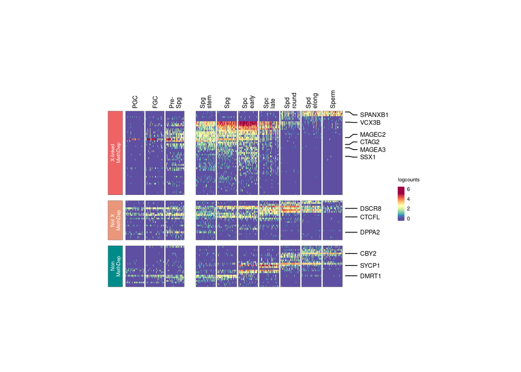

```r
fs <- 0
ncells <- 50
set.seed(123)
scale_limits <- c(0, 5)
label_fs <- 6

ht_testis <- draw_testis_heatmap(my_genes,
                                 gene_to_label = c("SPANXB1", "VCX3B", "MAGEC2",
                                                   "CTAG2", "MAGEA3", "SSX1",
                                                   "DSCR8", "CTCFL", "DPPA2",
                                                   "CBY2", "SYCP1", "DMRT1"),
                                 ncells_max = ncells,
                                 font_size = fs,
                                 scale_lims = scale_limits,
                                 title_fs = 6,
                                 h_width = 5,
                                 h_height = 6,
                                 clusterRow  = FALSE,
                                 show_legend = TRUE,
                                 label_fonsize = label_fs,
                                 clust_method = "centroid")


male_FGC_ht <- draw_FGC_heatmap(my_genes,
                                ncells_max = ncells,
                                sex = c("M"),
                                clusterRow = FALSE,
                                h_width = 2,
                                h_height = 6,
                                font_size = fs,
                                title_fs = 6,
                                scale_lims = scale_limits,
                                show_legend = FALSE)



ht_list <- male_FGC_ht + ht_testis

draw(ht_list, main_heatmap = "logcounts",
     merge_legend = TRUE)
```

```r
pdf(file = paste0("../figs/Fig6A_Expression_in_MALE_FGC_and_adult_testis.pdf"))
draw(ht_list, main_heatmap = "logcounts",
     merge_legend = TRUE, ht_gap = unit(0.1, "mm"))
dev.off()
```

## Fig 7A: Female germcells Expression (fetal + adult)

```r
fs <- 0
ncells <- 50
set.seed(123)

to_label <- c("DDX53", "TGIF2LX", #"VCX",
              "PAGE2", "PAGE5",
              "MAGEB2", "MAGEB1", "MAGEC1", "FTHL17", #"SAGE1",
              "DSCR8", "BRDT", "RBM46", "DCAF4L2", "CTCFL", "RNF17",
              "NLRP4", "LINC01413", "FAM217A", "LIN28A", "MEIOB", "MAJIN", "LINC01511")
to_label[!to_label%in% CT_genes$external_gene_name]
```

```
## character(0)
```

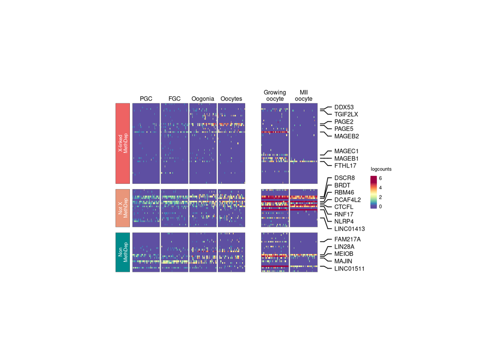

```r
ht_oocytes <- draw_oocytes_heatmap(my_genes,
                                   gene_to_label = to_label,
                                   label_fonsize = label_fs,
                                 ncells_max = ncells,
                                 font_size = fs,
                                 scale_lims = scale_limits,
                                 title_fs = 6,
                                 h_width = 2,
                                 h_height = 6,
                                 column_name_rot = 0,
                                 clusterRow  = FALSE,
                                 show_legend = TRUE,
                                 clust_method = "centroid",
                                 show_right_annot = FALSE,
                                 show_top_annot = FALSE,
                                 top_annot = "Stage")


female_FGC_ht <- draw_FGC_heatmap(my_genes,
                                ncells_max = ncells,
                                sex = c("F"),
                                clusterRow = FALSE,
                                h_width = 4,
                                h_height = 6,
                                column_name_rot = 0,
                                font_size = fs,
                                title_fs = 6,
                                scale_lims = scale_limits,
                                show_legend = FALSE)


ht_list <- female_FGC_ht + ht_oocytes

draw(ht_list, main_heatmap = "logcounts",
    merge_legend = TRUE)
```

```r
pdf(file = paste0("../figs/Fig7A_Expression_in_FEMALE_germcells.pdf"))
#, width = 6, height = 4)
draw(ht_list, main_heatmap = "logcounts",
    merge_legend = TRUE, ht_gap = unit(0.1, "mm"))
dev.off()
```

# Fig 6B: Repression of X-linked CG genes coincides with MSCI

- Calculated mean expression in each cell type
- Removed genes never expressed in pre-meiotic germ cells
- Calculated mean expression by chr
  - for Autosomial genes (not CG genes),
  - X-linked (not CG genes),
  - X-linked CG genes

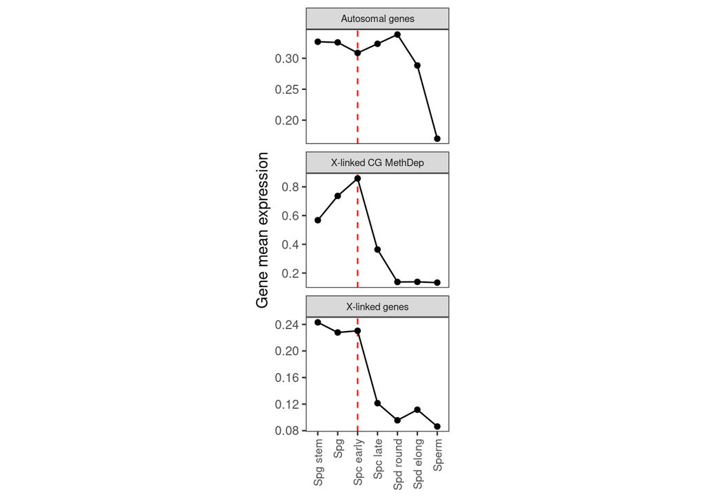

```r
testis_sce <- CTdata::testis_sce()

levels(testis_sce$type)[c(7,8)] <- "Sperm"
levels(testis_sce$type) <- c("Spermatogonial\nstem cells", "Spermatogonia",
                             "Early\nspermatocytes", "Late\nspermatocytes",
                             "Round\nspermatids", "Elongated\nspermatids",
                             "Sperm", "Macrophage", "Endothelial", "Myoid",
                             "Sertoli", "Leydig" )
somatic <- c("Macrophage", "Endothelial", "Myoid", "Sertoli", "Leydig")
testis_sce <- testis_sce[, !testis_sce$type %in% somatic]
testis_sce$type <- droplevels(testis_sce$type)

# Mean expression level per gene and per cell type
mean_gene_counts_by_type <- as_tibble(assay(testis_sce, "logcounts"),
                                      rownames = "gene") %>%
  pivot_longer(names_to = "cell", values_to = "count", -gene) %>%
  left_join(as_tibble(colData(testis_sce), rownames = "cell") %>%
              dplyr::select(cell, type)) %>%
  group_by(gene, type) %>%
  summarise(mean_count = mean(count)) %>%
  left_join(all_genes %>%
              dplyr::select(external_gene_name, chr) %>%
              dplyr::rename(gene = external_gene_name))

pre_meiotic <- c("Spermatogonial\nstem cells", "Spermatogonia",
                 "Early\nspermatocytes")

# To remove later on genes never detected in premeiotic cells
genes_never_expressed_in_premeiotic <- mean_gene_counts_by_type %>%
  filter(type %in% pre_meiotic) %>%
  group_by(gene) %>%
  mutate(mean_count_in_premeiotic = mean(mean_count)) %>%
  filter(mean_count_in_premeiotic == 0) %>%
  pull(gene)

Xmet <- CT_genes %>%
  filter(regulated_by_methylation) %>%
  filter(X_linked) %>%
  pull(external_gene_name)

# Mean expression level per chromosome and per cell type
# Removed CT genes MethDep from the genes
# Removed genes never_expressed_in_premeiotic_cells
mean_gene_counts_by_chromosome_and_by_type <- mean_gene_counts_by_type %>%
  filter(!gene %in% Xmet) %>%
  filter(!gene %in% genes_never_expressed_in_premeiotic) %>%
  filter(chr %in% c(1:22, "X")) %>%
  mutate(group = case_when(chr %in% 1:22 ~ "Autosomal genes",
                           chr == "X" ~ "X-linked genes")) %>%
  group_by(group, type) %>%
  summarize(gene_expression_mean = mean(mean_count)) %>%
  mutate(type = factor(type, levels = levels(mean_gene_counts_by_type$type)))

# Mean expression level of CTgenes MethDep per cell type
# Removed genes never_expressed_in_premeiotic_cells
mean_CT_counts_by_chromosome_and_by_type <- mean_gene_counts_by_type %>%
  filter(gene %in% Xmet) %>%
  filter(!gene %in% genes_never_expressed_in_premeiotic) %>%
  mutate(group = 'X-linked CG MethDep') %>%
  group_by(group, type) %>%
  summarize(gene_expression_mean = mean(mean_count)) %>%
  mutate(type = factor(type, levels = levels(mean_gene_counts_by_type$type)))

levels(mean_gene_counts_by_chromosome_and_by_type$type) <-
  c("Spg stem", "Spg", "Spc early", "Spc late", "Spd round", "Spd elong", "Sperm")
levels(mean_CT_counts_by_chromosome_and_by_type$type) <-
  c("Spg stem", "Spg", "Spc early", "Spc late", "Spd round", "Spd elong", "Sperm")


fig <- rbind(mean_gene_counts_by_chromosome_and_by_type,
             mean_CT_counts_by_chromosome_and_by_type) %>%
  ggplot(aes(x = type, y = gene_expression_mean, group = group)) + #, color = group)) +
  geom_vline(xintercept = 3, color = "red", linetype = "dashed")+
  geom_point() + geom_line() +
  theme_bw() +
  theme(axis.text.x = element_text(angle = 90, hjust = 1, vjust = 0.5, size = 8),
        axis.title.x = element_text(size = 0),
        legend.position = "none",
        panel.grid = element_blank(),
        aspect.ratio = 0.8,
        strip.text.x = element_text(size = 7)) +
  xlab("Spermatogenesis stage") +
  ylab("Gene mean expression") +
  facet_wrap(~ group, scales = "free_y", ncol = 1)

fig
```

```r
pdf(file = paste0("../figs/Fig6B_Repression_of_MethDep_and_MSCI.pdf"), width = 2.5, height = 4)
fig
dev.off()
```

```r
# Number of genes in each group:
x <- mean_gene_counts_by_type %>%
  filter(!gene %in% Xmet) %>%
  filter(!gene %in% genes_never_expressed_in_premeiotic) %>%
  filter(chr %in% c(1:22, "X")) %>%
  mutate(group = case_when(chr %in% 1:22 ~ "Autosomal genes",
                                chr == "X" ~ "X-linked genes")) %>%
  dplyr::select(gene, group) %>% unique()

y <- mean_gene_counts_by_type %>%
  filter(gene %in% Xmet) %>%
  mutate(group = 'X-linked CG MethDep') %>%
  dplyr::select(gene, group) %>% unique()

n_gene_per_group <- rbind(x, y)

flextable(enframe(table(n_gene_per_group$group),
                  name = "Group", value = "number of gene"),
                     cwidth = 1.5,
                     cheight = 0.25) %>%
  set_caption(as_paragraph(
    as_chunk("Number of analysed genes",
             props = fp_text_default(font.family = "Arial",
                                                 font.size = 10))),
    word_stylename = "Table Caption",
    align_with_table = TRUE
  )
```

Number of analysed genes

| Group | number of gene |
| --- | --- |
| Autosomal genes | 18205 |
| X-linked CG MethDep | 59 |
| X-linked genes | 696 |

# Fig 6D: CG expression and methylation in Male FGC

## Expression

Proportions of positive cells

=> proportion of count values in each group that are non-zero

```r
my_genes <- CT_genes$external_gene_name[CT_genes$external_gene_name %in% rownames(FGC_sce)]

dds <- scuttle::summarizeAssayByGroup(FGC_sce,
                                      assay.type = "logcounts",
                            ids = FGC_sce$type,
                            statistics = "prop.detected")

dds$type <- dds$ids
rownames(colData(dds)) <- dds$ids
colnames(dds) <- dds$ids
dds$sex <- c(rep("F", 4), rep("M", 3))

bilan_exp <- as_tibble(assay(dds[my_genes, ]), rownames = "gene") %>%
  pivot_longer(names_to = "type_sex", values_to = "proportion_of_pos", -gene) %>%
  left_join(CT_genes %>%
              dplyr::select(external_gene_name, regulated_by_methylation, X_linked) %>%
              dplyr::rename(gene = external_gene_name)) %>%
  filter(!is.na(regulated_by_methylation)) %>%
  mutate(CT_group = case_when(regulated_by_methylation & X_linked ~ "X-linked MethDep",
                              regulated_by_methylation & !X_linked ~ "Not X MethDep",
                              !regulated_by_methylation ~ "Non-MethDep")) %>%
   mutate(CT_group = factor(CT_group,
                            levels = c("X-linked MethDep",
                                       "Not X MethDep",
                                       "Non-MethDep"))) %>%
  mutate(type_sex = factor(type_sex, levels = levels(FGC_sce$type) )) %>%
  left_join(as_tibble(colData(dds)) %>% dplyr::rename(type_sex = type))

levels(bilan_exp$type_sex) <- c("PGC", "FGC", "Oogonia", "Oocyte", "PGC", "FGC", "Pre-SpG")
bilan_exp$sex <- factor(bilan_exp$sex)
levels(bilan_exp$sex) <- c("Female FGCs", "Male FGCs" )

library(ggh4x)
strip <- strip_themed(background_y = elem_list_rect(fill = CT_group_colors))

my_colors <- CT_group_colors
names(my_colors) <- c("X-linked\nMethDep", "Not X\nMethDep","Non-MethDep")

fig_expression_in_Male_FGC <- bilan_exp %>%
  filter(sex == "Male FGCs") %>%
  mutate(sex = "scRNAseq\nMale gonad") %>%
  filter(CT_group != "Non-MethDep") %>%
  mutate(CT_group = case_when(CT_group == "X-linked MethDep" ~ "X-linked\nMethDep",
                              CT_group == "Not X MethDep" ~ "Not X\nMethDep")) %>%
  mutate(CT_group = factor(CT_group, levels =  c("X-linked\nMethDep", "Not X\nMethDep"))) %>%
  ggplot(aes(x = type_sex, y = proportion_of_pos)) +
  scale_color_manual(values = CT_group_colors) +
  geom_boxplot(data = bilan_exp %>%
                 filter(sex == "Male FGCs") %>%
                 mutate(sex = "scRNAseq\nMale gonad") %>%
                 filter(CT_group != "Non-MethDep") %>%
                 mutate(CT_group = case_when(CT_group == "X-linked MethDep" ~ "X-linked\nMethDep",
                                             CT_group == "Not X MethDep" ~ "Not X\nMethDep")) %>%
                 mutate(CT_group = factor(CT_group, levels =  c("X-linked\nMethDep", "Not X\nMethDep"))) ,
               aes(x = type_sex, y = proportion_of_pos, fill = CT_group),
               alpha = 0.5,
               outliers = F,
               varwidth = TRUE,
               linewidth = 0.3) +
  scale_fill_manual(values = my_colors) +
  facet_grid2(CT_group ~ sex, drop = T,
              switch = "y",
              scales = "free_x",
              strip = strip) +#, space = "free") +#, switch = "y") +
  theme_bw() +
  theme(aspect.ratio = 1.5,
        axis.text.x = element_text(angle = 0,
                                   size = 8,
                                   vjust = 0.5,
                                   hjust = 0.5,
                                   face = "bold"),
        axis.title.y = element_text(size = 12),
        axis.title.x = element_text(size = 0),
        panel.grid.major.x = element_blank(),
        panel.grid.minor.x = element_blank(),
        legend.position = "none",
        strip.text.x = element_text(size = 10),
        strip.text.y = element_text(size = 10, color = "white", face = "bold"),
        strip.placement.y = "inside",
        strip.background.y = element_rect(fill=CT_group_colors[2]),
        strip.background.x = element_blank() ) +
  ylab("Proportions of positive cells") +
  xlab("Fetal cell stages")

bilan_exp %>%
  filter(sex == "Male FGCs") %>%
  mutate(sex = "scRNAseq\nMale gonad") %>%
  filter(CT_group != "Non-MethDep") %>%
  mutate(CT_group = case_when(CT_group == "X-linked MethDep" ~ "X-linked\nMethDep",
                              CT_group == "Not X MethDep" ~ "Not X\nMethDep")) %>%
  mutate(CT_group = factor(CT_group, levels =  c("X-linked\nMethDep", "Not X\nMethDep"))) %>%
  dplyr::select(gene, CT_group) %>%
  unique() %>%
  pull(CT_group) %>%
  table()
```

```
## .
## X-linked\nMethDep    Not X\nMethDep
##                49                23
```

## Methylation

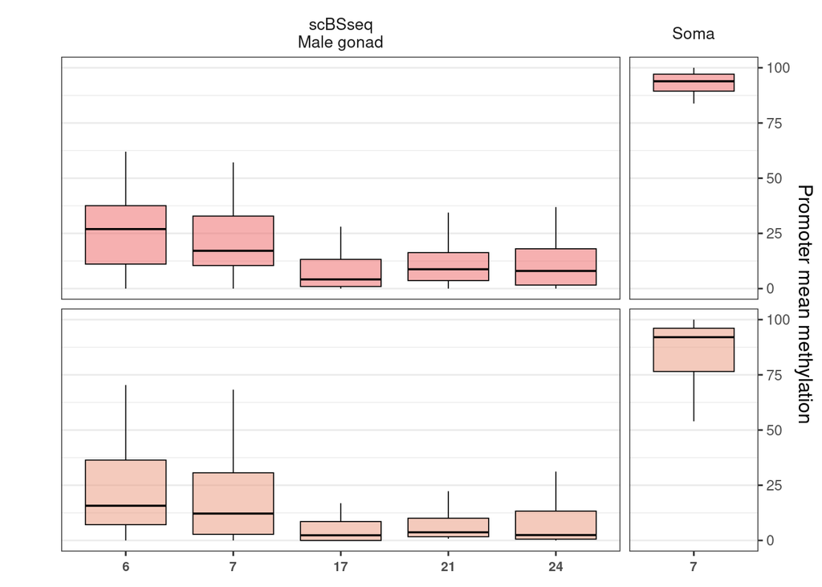

```r
mean_methylation_in_FGC <- CTdata::mean_methylation_in_FGC()

bilan <- as_tibble(assay(mean_methylation_in_FGC), rownames = "gene") %>%
  filter(gene %in% CT_genes$external_gene_name) %>%
  pivot_longer(names_to = "sample", values_to = "met", -gene) %>%
  left_join(CT_genes %>%
              dplyr::select(external_gene_name, regulated_by_methylation, X_linked) %>%
              dplyr::rename(gene = external_gene_name)) %>%
  filter(!is.na(regulated_by_methylation)) %>%
  mutate(CT_group = case_when(regulated_by_methylation & X_linked ~ "X-linked MethDep",
                              regulated_by_methylation & !X_linked ~ "Not X MethDep",
                              !regulated_by_methylation ~ "Non-MethDep")) %>%
  mutate(CT_group = factor(CT_group,
                           levels = c("X-linked MethDep",
                                      "Not X MethDep",
                                      "Non-MethDep"))) %>%
  left_join(as_tibble(colData(mean_methylation_in_FGC)) %>%
              dplyr::select(sample, group, type, time_week, sex, sex_time, sex_type, type) %>%
              dplyr::rename(FGC_group = group)) %>%
  #filter(gene == "DCAF8L2") %>%
  group_by(CT_group, gene, type, time_week, sex) %>%
  summarise(mean_met = mean(met, na.rm = TRUE),
            met_sd = sd(met, na.rm = TRUE),
            median_met = median(met, na.rm = TRUE)) %>%
  mutate(type_sex = case_when(type == "FGC" & sex == "F" ~ "Female FGC",
                              type == "FGC" & sex == "M" ~ "Male FGC",
                              type == "Soma"& sex == "F" ~ "Somatic cells",
                              type == "Soma"& sex == "M" ~ "Somatic cells")) %>%
  mutate(sex = case_when(sex == "F" ~ "Female",
                         sex == "M" ~ "Male")) %>%
  mutate(Group = paste0(CT_group, type)) %>%
  mutate(Group = factor(Group, levels = c("X-linked MethDepFGC",
                                          "X-linked MethDepSoma",
                                          "Not X MethDepFGC",
                                          "Not X MethDepSoma",
                                          "Non-MethDepFGC",
                                          "Non-MethDepSoma"))) %>%
  mutate(Type = case_when(type == "Soma" ~ "Somatic cells",
                          type == "FGC" ~ "FGC"))

library(ggh4x)
strip <- strip_themed(background_y = elem_list_rect(fill = CT_group_colors))

fig_met_in_Male_FGC <- bilan %>%
  filter(sex == "Male") %>%
  mutate(type_sex = case_when(type_sex == "Male FGC" ~"scBSseq\nMale gonad",
                              type_sex == "Somatic cells" ~"Soma")) %>%
  filter(CT_group != "Non-MethDep") %>%
  mutate(CT_group = case_when(CT_group == "X-linked MethDep" ~ "X-linked\nMethDep",
                           CT_group == "Not X MethDep" ~ "Not X\nMethDep")) %>%
  mutate(CT_group = factor(CT_group, levels =  c("X-linked\nMethDep", "Not X\nMethDep"))) %>%
  mutate(time_week = factor(time_week,
                            levels = c("6", "7", "8", "9", "10", "17", "21", "24"))) %>%
  ggplot(aes(x = time_week, y = mean_met, color = CT_group, group = time_week)) +
  #geom_jitter(size = .2, alpha = 1) +
  geom_boxplot(data = bilan %>%
  filter(sex == "Male") %>%
  mutate(type_sex = case_when(type_sex == "Male FGC" ~"scBSseq\nMale gonad",
                              type_sex == "Somatic cells" ~"Soma")) %>%
  filter(CT_group != "Non-MethDep") %>%
  mutate(CT_group = case_when(CT_group == "X-linked MethDep" ~ "X-linked\nMethDep",
                           CT_group == "Not X MethDep" ~ "Not X\nMethDep")) %>%
  mutate(CT_group = factor(CT_group, levels =  c("X-linked\nMethDep", "Not X\nMethDep"))) %>%
  mutate(time_week = factor(time_week,
                            levels = c("6", "7", "8", "9", "10", "17", "21", "24"))),
  aes(x = time_week, y = mean_met, color = CT_group, group = time_week, fill = CT_group),
               linewidth = 0.3,
               alpha = 0.5, color = "black",
               outliers = F) +
  scale_color_manual(values = CT_group_colors) +
  scale_fill_manual(values = my_colors) +
  facet_grid2(CT_group ~ type_sex,
              scales = "free_x",
              space = "free",
             drop = TRUE,
             #strip = strip,
             switch = "y"
             ) +
  theme_bw() +
  theme(#aspect.ratio = 2,
        axis.text.x = element_text(angle = 0,
                                   size = 8,
                                   vjust = 0.5,
                                   hjust = 0.5,
                                   face = "bold"),
        axis.title.y = element_text(size = 12),
        axis.title.x = element_text(size = 0),
        panel.grid.major.x = element_blank(),
        panel.grid.minor.x = element_blank(),
        legend.position = "none",
        strip.placement.y = "right",
        strip.text.x = element_text(size = 10),
        strip.text.y = element_text(size = 10, color = "white", face = "bold"),
        strip.background = element_blank(),
        strip.x = element_blank()) +
  scale_y_continuous(position = "right")+
  #scale_y_log10() +
    ylab("Promoter mean methylation") +
  xlab("Time (week)")
fig_met_in_Male_FGC
```

```r
bilan %>%
  filter(CT_group == "X-linked MethDep", sex == "Male", type == "FGC") %>%
  mutate(timepoints = case_when(time_week <= 7 ~ "6-7W",
                                time_week >= 17 ~ ">17W")) %>%
  ungroup() %>%
  group_by(timepoints) %>%
  dplyr::summarise("methylation (mean)" = mean(mean_met, na.rm = TRUE),
                   "methylation (median)" = median(mean_met, na.rm = TRUE)) %>%
  DT::datatable()
```

|  | timepoints | methylation (mean) | methylation (median) |
| --- | --- | --- | --- |
| 1 | 6-7W | 24.73474140801487 | 22.54931260454758 |
| 2 | &gt;17W | 12.18748859705254 | 6.771622142791498 |

## Fig 6D: Exp + Meth

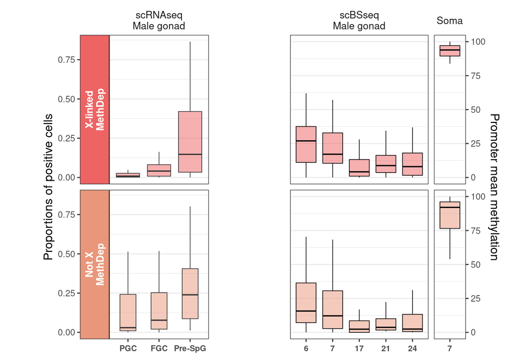

```r
gridExtra::grid.arrange(fig_expression_in_Male_FGC, fig_met_in_Male_FGC, ncol = 2)
```

```r
pdf(file = "../figs/Fig6D_Expression_and_Met_in_Male_FGC.pdf", width = 5, height = 3)
gridExtra::grid.arrange(fig_expression_in_Male_FGC, fig_met_in_Male_FGC, ncol = 2)
dev.off()
```

# Fig 6F: expression and methylation in Male FGC: Selected examples

## Initial gene selection

```r
X_MethDep_genes <- c("SSX1", "VCX", "PAGE2", "MAGEC2", "MAGEB16")
notX_MethDep_genes <- c("RNF17", "CTCFL")
#not_MethDep_genes <- c("DMRT1", "SYCP1")
selected_genes <- c(X_MethDep_genes, notX_MethDep_genes)

strip <- strip_themed(background_y = elem_list_rect(fill = c(rep("indianred2", 5), rep(CT_group_colors[2], 2))))

bilan_exp_selected <-bilan_exp %>%
  filter(sex == "Male FGCs") %>%
  filter(gene %in% selected_genes) %>%
  mutate(gene = factor(gene, levels = selected_genes)) %>%
  left_join(CT_genes %>%
              dplyr::select(external_gene_name, regulated_by_methylation, X_linked) %>%
              dplyr::rename(gene = external_gene_name)) %>%
  filter(!is.na(regulated_by_methylation)) %>%
  mutate(CT_group = case_when(regulated_by_methylation & X_linked ~ "X-linked MethDep",
                              regulated_by_methylation & !X_linked ~ "Not X MethDep",
                              !regulated_by_methylation ~ "Non-MethDep"))
bilan_exp_selected$gene <- factor(bilan_exp_selected$gene, levels = selected_genes)

fig_exp <- bilan_exp_selected %>%
    ggplot(aes(x = type_sex, y = proportion_of_pos, group = gene , color = CT_group)) +
    geom_point()+
    geom_line() +
  scale_color_manual(values = CT_group_colors)+
  facet_grid2( gene ~ ., strip = strip, switch = "y") +
  theme_bw() +
  theme(aspect.ratio = .5,
        axis.title.x = element_blank(),
        axis.text.x = element_text(size = 8, face = "bold"),
        axis.title.y = element_text(size = 12),
        panel.grid.major.x = element_blank(),
        panel.grid.minor.x = element_blank(),
        strip.text.y = element_text(size = 7, face = "bold"),
        strip.placement = "outside") +
  ylab("Proportion of positive cells")



bilan_met_selected <- bilan %>%
  ungroup() %>%
  filter(gene %in% selected_genes) %>%
  filter(type_sex == "Male FGC") %>%
  mutate(time_week = factor(time_week))

bilan_met_selected$gene <- factor(bilan_met_selected$gene, levels = selected_genes)

fig_met <- bilan_met_selected %>%
  ggplot(aes(x = time_week, y = mean_met, group = gene, color = CT_group)) +
  geom_point()+
    geom_line() +
  #facet_grid2( gene ~ ., strip = strip) +
  facet_grid( gene ~ .) +
  scale_color_manual(values = CT_group_colors)+
  theme_bw() +
  theme(aspect.ratio = .4,
        axis.title.x = element_blank(),
        axis.text.x = element_text(size = 8, face = "bold"),
        axis.title.y = element_text(size = 12),
        panel.grid.major.x = element_blank(),
        panel.grid.minor.x = element_blank(),
        strip.text.y = element_text(size = 0, face = "bold"),
        strip.background = element_blank()) +
  ylab("Promoter mean methylation")
```

Expression

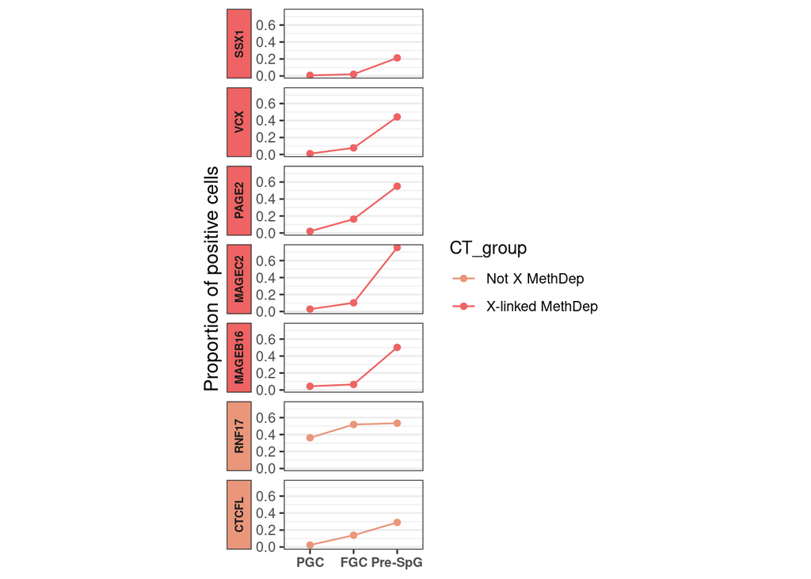

```r
fig_exp
```

Methylation

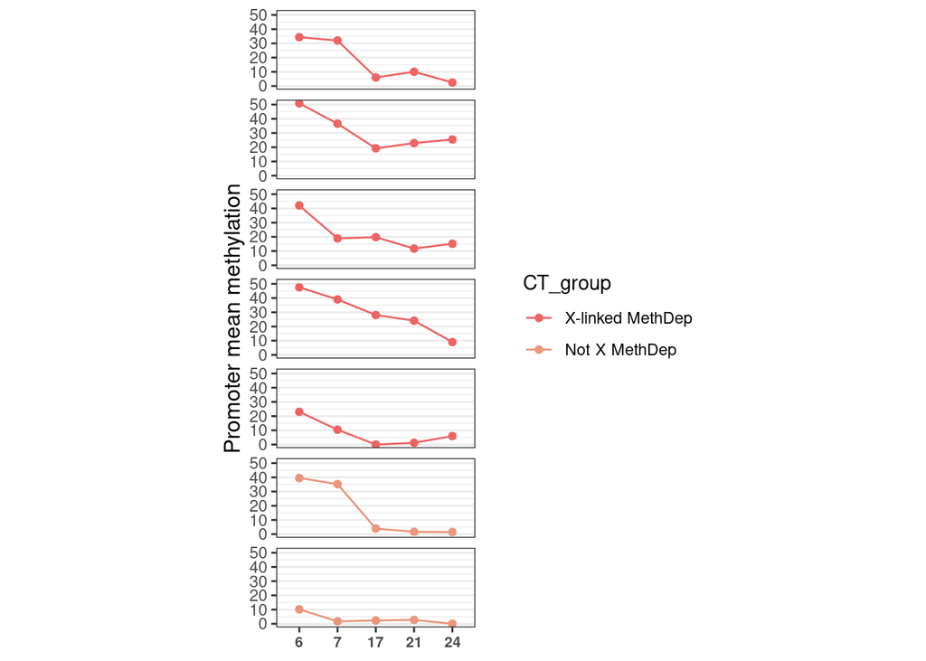

```r
fig_met
```

```r
#gridExtra::grid.arrange(fig_exp, fig_met, ncol = 3)

pdf(file = "../figs/Fig6F_Examples.pdf")#, width = 3, height = 5)
gridExtra::grid.arrange(fig_exp, fig_met, ncol = 2)
dev.off()
```

# Fig 7D: Methylation in Female FGC

```r
met_thr <- 75

Genes_methylated_in_soma <- as_tibble(assay(mean_methylation_in_FGC), rownames = "gene") %>%
  pivot_longer(names_to = "sample", values_to = "met", -gene) %>%
  left_join(as_tibble(colData(mean_methylation_in_FGC)) %>%
              dplyr::select(sample, group, type, time_week, sex, sex_time, sex_type, type) %>%
              dplyr::rename(FGC_group = group)) %>%
  filter(type == "Soma") %>%
  mutate(sex = case_when(sex == "F" ~ "Female",
                         sex == "M" ~ "Male")) %>%
  group_by(gene, type, time_week, sex) %>%
  summarise(mean_met = mean(met, na.rm = TRUE)) %>%
  ungroup() %>%
  dplyr::select(gene, sex, mean_met) %>%
  pivot_wider(names_from = sex, values_from = mean_met) %>%
  filter(Female >= met_thr, Male >= met_thr) %>%
  pull(gene)

MethDep <- CT_genes %>% filter(regulated_by_methylation)
bilan <- as_tibble(assay(mean_methylation_in_FGC), rownames = "gene") %>%
  filter(gene %in% Genes_methylated_in_soma | gene %in% MethDep$external_gene_name) %>%
  pivot_longer(names_to = "sample", values_to = "met", -gene) %>%
  left_join(all_genes %>%
              dplyr::select(external_gene_name, CT_gene_type, regulated_by_methylation, chr, X_linked) %>%
              dplyr::rename(gene = external_gene_name)) %>%
  filter(!is.na(regulated_by_methylation)) %>%
  mutate(CT_group = case_when(CT_gene_type != "CT_gene" & X_linked ~ "X-linked\nNon CG",
                              CT_gene_type != "CT_gene" & chr %in% c(1:22) ~ "Autosome\nNon CG",
                              CT_gene_type == "CT_gene" & X_linked & regulated_by_methylation ~ "X-linked\nMethDep",
                              CT_gene_type == "CT_gene" & !X_linked & regulated_by_methylation ~ "Not X\nMethDep")) %>%
  filter(!is.na(CT_group)) %>%
  mutate(CT_group = factor(CT_group)) %>%
  left_join(as_tibble(colData(mean_methylation_in_FGC)) %>%
              dplyr::select(sample, group, type, time_week, sex, sex_time, sex_type, type) %>%
              dplyr::rename(FGC_group = group)) %>%
  group_by(CT_group, gene, type, time_week, sex) %>%
  summarise(mean_met = mean(met, na.rm = TRUE),
            met_sd = sd(met, na.rm = TRUE),
            median_met = median(met, na.rm = TRUE)) %>%
  mutate(type_sex = case_when(type == "FGC" & sex == "F" ~ "Female FGC",
                              type == "FGC" & sex == "M" ~ "Male FGC",
                              type == "Soma"& sex == "F" ~ "Somatic cells",
                              type == "Soma"& sex == "M" ~ "Somatic cells")) %>%
  mutate(sex = case_when(sex == "F" ~ "Female",
                         sex == "M" ~ "Male")) %>%
  mutate(Group = paste0(CT_group, type, " ")) %>%
  mutate(Group = factor(Group, levels = c("X-linked MethDep FGC",
                                          "X-linked MethDep Soma",
                                          "Not X MethDep FGC",
                                          "Not X MethDep Soma",
                                          "Not X Non CG FGC",
                                          "Not X Non CG Soma",
                                          "X-linked Non CGF GC",
                                          "X-linked Non CG Soma")))

bilan$time_type <- paste0(bilan$type, " ", bilan$time_week, "W")
bilan$time_type <- factor(bilan$time_type , levels = c("Soma 7W", "Soma 8W", "FGC 6W", "FGC 7W", "FGC 8W", "FGC 9W", "FGC 10W", "FGC 17W", "FGC 21W", "FGC 24W"))
bilan$CT_group <- factor(bilan$CT_group, levels = c("X-linked\nMethDep", "Not X\nMethDep", "Autosome\nNon CG", "X-linked\nNon CG" ))

bilan %>% ungroup() %>% dplyr::select(CT_group, gene) %>% unique %>% pull(CT_group) %>% table()
```

```
## .
## X-linked\nMethDep    Not X\nMethDep  Autosome\nNon CG  X-linked\nNon CG
##                69                37              3695               137
```

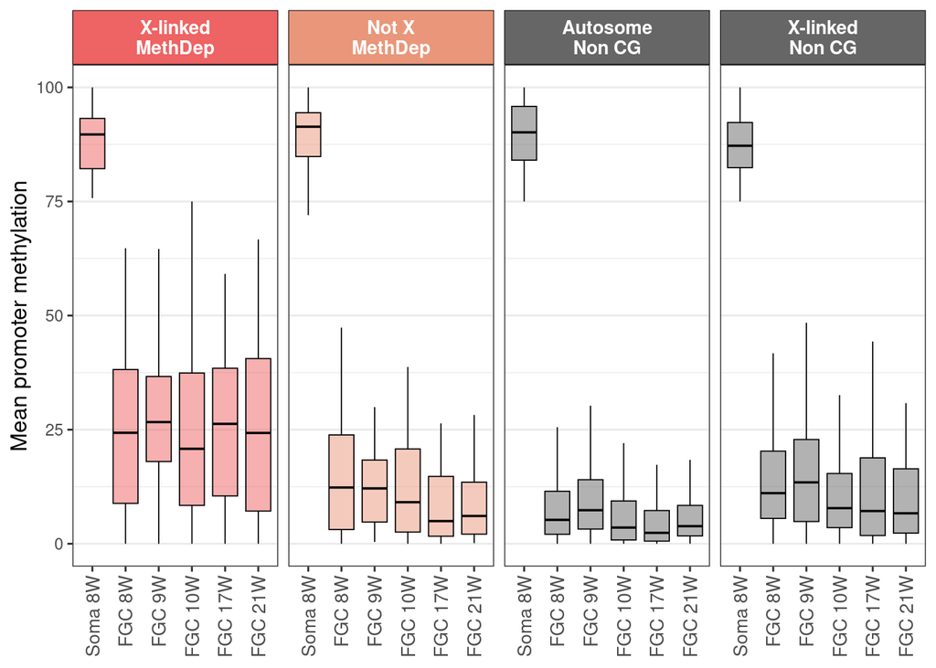

```r
library(ggh4x)
strip_group_colors <- c(CT_group_colors[1] , CT_group_colors[2] , "gray40", "gray40")
names(strip_group_colors) <- levels(bilan$CT_group)
strip <- strip_themed(background_x = elem_list_rect(fill = strip_group_colors))

fig <- bilan %>%
  filter(sex == "Female") %>%
  ggplot(aes(x = time_type, y = mean_met, fill = CT_group)) +
  geom_boxplot(linewidth = 0.3,
               alpha = 0.5,  color = "black",
               outliers = F) +
  scale_fill_manual(values = strip_group_colors) +
  facet_grid2( ~ CT_group ,  scales = "free_x", space = "free",
             drop = TRUE, strip = strip) +
  theme_bw() +
  theme(axis.text.x = element_text(angle = 90,
                                   size = 10,
                                   vjust = 0.5,
                                   hjust = 1),
        axis.title.y = element_text(size = 12),
        axis.title.x = element_blank(),
        panel.grid.major.x = element_blank(),
        panel.grid.minor.x = element_blank(),
        legend.position = "none",
        strip.text.y = element_text(size = 12),
        strip.text.x = element_text(size = 10, color = "white", face = "bold"),
        strip.background = element_blank()) +
    ylab("Mean promoter methylation") +
  xlab("Time (week)")

fig
```

```r
pdf(file = "../figs/Fig7D_met_in_Female_FGC.pdf", width = 6, height = 5)
fig
dev.off()
```

```r
bilan %>%
  filter(sex == "Female", type == "FGC") %>%
  ungroup() %>%
  group_by(CT_group, time_week) %>%
  dplyr::summarise("methylation (mean)" = mean(mean_met, na.rm = TRUE),
                   "methylation (median)" = median(mean_met, na.rm = TRUE)) %>%
  DT::datatable()
```

|  | CT_group | time_week | methylation (mean) | methylation (median) |
| --- | --- | --- | --- | --- |
| 1 | X-linked MethDep | 8 | 25.19187432484787 | 24.31821697087037 |
| 2 | X-linked MethDep | 9 | 28.19428527857611 | 26.66666666666667 |
| 3 | X-linked MethDep | 10 | 23.72330606173351 | 20.80376462158531 |
| 4 | X-linked MethDep | 17 | 30.57715525482034 | 26.27562680375181 |
| 5 | X-linked MethDep | 21 | 24.81860394510486 | 24.28358118856178 |
| 6 | Not X MethDep | 8 | 16.50239497877817 | 12.32607006831822 |
| 7 | Not X MethDep | 9 | 16.71608544495764 | 12.12473227749169 |
| 8 | Not X MethDep | 10 | 12.82058259904103 | 9.10678261296253 |
| 9 | Not X MethDep | 17 | 11.98710999840505 | 4.96175573418517 |
| 10 | Not X MethDep | 21 | 12.80514388995735 | 6.091080278789574 |

[output cut: 10 more lines]

```r
bilan %>%
  filter(sex == "Female", type == "FGC") %>%
  ungroup() %>%
  group_by(CT_group) %>%
  dplyr::summarise("methylation (mean)" = mean(mean_met, na.rm = TRUE),
                   "methylation (median)" = median(mean_met, na.rm = TRUE)) %>%
  DT::datatable()
```

|  | CT_group | methylation (mean) | methylation (median) |
| --- | --- | --- | --- |
| 1 | X-linked MethDep | 26.45611628981547 | 24.88054243736062 |
| 2 | Not X MethDep | 14.16626338222785 | 7.91544952597237 |
| 3 | Autosome Non CG | 8.386999842712791 | 4.365079365079366 |
| 4 | X-linked Non CG | 14.06218177602806 | 8.784578341555086 |

# Fig 7B: Proportion of CT genes expressed in Male and Female germ cells

## Using all datasets (FGC, oocytes and testis datasets)

- Estimate the proportion of cells in wich each gene is detected.
- Considered as “detected” if the gene is detected in more than 10% of a cell type

```r
FGC_sce <- CTdata::FGC_sce()
FGC_sce <- FGC_sce[, FGC_sce$low_ncounts == "False"]
FGC_sce <- FGC_sce[, FGC_sce$high_mito == "False"]


dds_FGC <- scuttle::summarizeAssayByGroup(FGC_sce,
                            ids = colData(FGC_sce)[, "type"],
                            statistics = "prop.detected")

testis_sce <- CTdata::testis_sce()
levels(testis_sce$type)[c(7,8)] <- "Sperm"
germcells <-  c("SSC", "Spermatogonia", "Early_spermatocyte",
                "Late_spermatocyte", "Round_spermatid",
                "Elongated_spermatid", "Sperm")

testis_sce <- testis_sce[, testis_sce$type %in% germcells]
testis_sce$type <- factor(testis_sce$type, levels = germcells)

dds_testis <- scuttle::summarizeAssayByGroup(testis_sce,
                            ids = colData(testis_sce)[, "type"],
                            statistics = "prop.detected")


oocytes_sce <- CTdata::oocytes_sce()
oocytes_sce <- oocytes_sce[, oocytes_sce$type %in% c("Growing oocytes", "Metaphase II")]
oocytes_sce$type <- droplevels(oocytes_sce$type)

dds_oocytes <- scuttle::summarizeAssayByGroup(oocytes_sce,
                            ids = colData(oocytes_sce)[, "type"],
                            statistics = "prop.detected")
```

- CG Genes detected in more than 10% of any cell type is considered as expressed in this cell type
- Kept only CG genes detected in at least one cell type of any of the 3 datasets
- Removed Y-linked CG genes from the analysis

```r
genes_detected_in_dds_FGC <- names(dds_FGC)[rowMaxs(assay(dds_FGC[,])) > 0.1]

selected_genes <- CT_genes %>%
  filter(chr != "Y") %>%
  filter(external_gene_name %in% genes_detected_in_dds_FGC)


bilan_FGC <- tibble(gene = names(rowSums(assay(dds_FGC[selected_genes$external_gene_name,
                                                   c("F_PGC", "F_GC", "F_oogonia", "F_oocyte")]) > 0.1) > 0),
                detected_in_female_FGC = as.vector(rowSums(assay(dds_FGC[selected_genes$external_gene_name,
                                                                     c("F_PGC", "F_GC", "F_oogonia", "F_oocyte")]) > 0.1) > 0),
                detected_in_male_FGC = as.vector(rowSums(assay(dds_FGC[selected_genes$external_gene_name,
                                                                   c("M_PGC", "M_GC", "M_pre_spermatogonia")]) > 0.1) > 0))
```

```r
genes_detected_in_dds_testis <- names(dds_testis)[rowMaxs(assay(dds_testis[,], na.rm = TRUE)) > 0.1]

selected_genes <- CT_genes %>%
  filter(chr != "Y") %>%
  filter(external_gene_name %in% genes_detected_in_dds_testis)

bilan_testis <- tibble(gene = names(rowSums(assay(dds_testis[selected_genes$external_gene_name, ]) > 0.1) > 0),
                detected_in_male_adult = as.vector(rowSums(assay(dds_testis[selected_genes$external_gene_name, ]) > 0.1) > 0))
```

```r
genes_detected_in_dds_oocytes <- names(dds_oocytes)[rowMaxs(assay(dds_oocytes[,], na.rm = TRUE)) > 0.1]

selected_genes <- CT_genes %>%
  filter(chr != "Y") %>%
  filter(external_gene_name %in% genes_detected_in_dds_oocytes)

bilan_oocytes <- tibble(gene = names(rowSums(assay(dds_oocytes[selected_genes$external_gene_name, ]) > 0.1) > 0),
                detected_in_Female_oocytes = as.vector(rowSums(assay(dds_oocytes[selected_genes$external_gene_name, ]) > 0.1) > 0))
```

```r
bilan <- full_join(bilan_FGC,
          bilan_testis) %>%
  full_join(bilan_oocytes)

bilan_by_male_female <- bilan %>%
rowwise() %>%
  mutate(detected_in_male = sum(detected_in_male_FGC, detected_in_male_adult, na.rm = TRUE)) %>%
  mutate(detected_in_female = sum(detected_in_female_FGC, detected_in_Female_oocytes, na.rm = TRUE)) %>%
  left_join(CT_genes %>%
              dplyr::select(external_gene_name, chr, regulated_by_methylation, X_linked) %>%
              dplyr::rename(gene = external_gene_name)) %>%
  filter(chr!= "Y") %>%
  mutate(group = case_when(regulated_by_methylation & X_linked ~ "X-linked\nMethDep",
                           regulated_by_methylation & !X_linked ~ "Autosomal\nMethDep",
                           !regulated_by_methylation  ~ "Non\nMethDep"))


bilan_by_group <- bilan_by_male_female %>%
  group_by(group) %>%
  summarise("F" = sum(detected_in_female),
            "M" = sum(detected_in_male))


flextable(bilan_by_group,
                     cwidth = 1.5,
                     cheight = 0.25) %>%
  set_caption(as_paragraph(
    as_chunk("Among genes detected in FGC, testis or oocytes dataset",
             props = fp_text_default(font.family = "Arial",
                                                 font.size = 10))),
    word_stylename = "Table Caption",
    align_with_table = TRUE
  )
```

Among genes detected in FGC, testis or oocytes dataset

| group | F | M |
| --- | --- | --- |
| Autosomal MethDep | 32 | 37 |
| Non MethDep | 28 | 36 |
| X-linked MethDep | 24 | 76 |

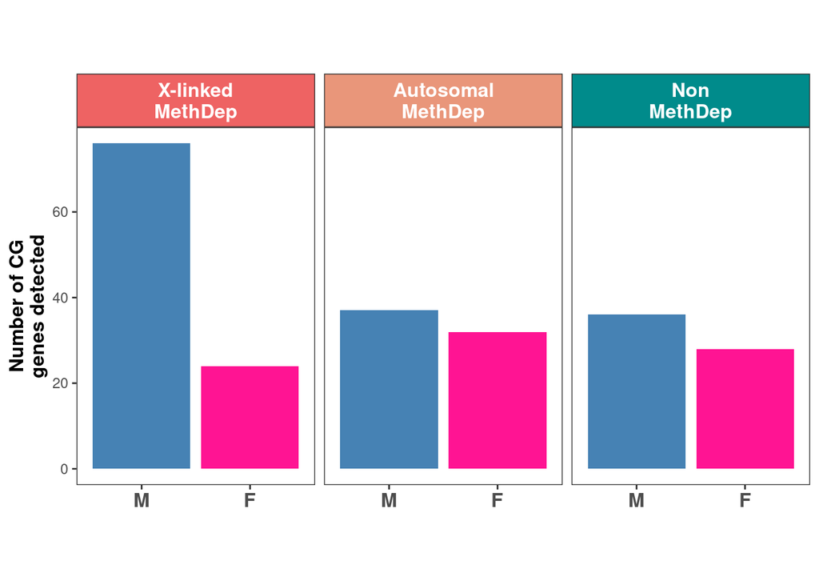

```r
bilan_by_group$group <- factor(bilan_by_group$group, levels = c("X-linked\nMethDep", "Autosomal\nMethDep", "Non\nMethDep"   ))


names(CT_group_colors) <- c("X-linked\nMethDep", "Autosomal\nMethDep", "Non\nMethDep"   )
strip <- strip_themed(background_x = elem_list_rect(fill = CT_group_colors))


bilan_by_group <- bilan_by_group %>%
  pivot_longer(names_to = "detected_where", values_to = "Number of detected CG genes", -group)

bilan_by_group$detected_where <- factor(bilan_by_group$detected_where, levels = c("M", "F"   ))


fig <- bilan_by_group %>%
  ggplot(aes(x = detected_where, y = `Number of detected CG genes`, fill = detected_where)) +
  geom_col() +
  scale_fill_manual(values = sex_colors) +
  facet_grid2(~ group, strip = strip) +
  theme_bw() +
  theme(aspect.ratio = 1.5,
        panel.grid = element_blank(),
        axis.title.x = element_blank(),
        axis.title.y = element_text(size = 12, face = "bold"),
        axis.text.x = element_text(size = 12, face = "bold"),
        legend.position = "none",
        strip.text.x = element_text(size = 12, color = "white", face = "bold")) +
  ylab("Number of CG\ngenes detected")


fig
```

```r
pdf(file = "../figs/Fig7B_Genes_detected_in_Male_and_Female.pdf", width = 4, height = 3)
fig
dev.off()
```

```r
bilan_by_group$group <- gsub("\n", x = bilan_by_group$group, replacement = " ")
knitr::kable(bilan_by_group[1:2,])
```

| group | detected_where | Number of detected CG genes |
| --- | --- | --- |
| Autosomal MethDep | F | 32 |
| Autosomal MethDep | M | 37 |

```r
chisq.test(bilan_by_group$`Number of detected CG genes`[1:2], p = c(0.5, 0.5))
```

```
##
##  Chi-squared test for given probabilities
##
## data:  bilan_by_group$`Number of detected CG genes`[1:2]
## X-squared = 0.36232, df = 1, p-value = 0.5472
```

```r
knitr::kable(bilan_by_group[3:4,])
```

| group | detected_where | Number of detected CG genes |
| --- | --- | --- |
| Non MethDep | F | 28 |
| Non MethDep | M | 36 |

```r
chisq.test(bilan_by_group$`Number of detected CG genes`[3:4], p = c(0.5, 0.5))
```

```
##
##  Chi-squared test for given probabilities
##
## data:  bilan_by_group$`Number of detected CG genes`[3:4]
## X-squared = 1, df = 1, p-value = 0.3173
```

```r
knitr::kable(bilan_by_group[5:6,])
```

| group | detected_where | Number of detected CG genes |
| --- | --- | --- |
| X-linked MethDep | F | 24 |
| X-linked MethDep | M | 76 |

```r
chisq.test(bilan_by_group$`Number of detected CG genes`[5:6], p = c(0.5, 0.5))
```

```
##
##  Chi-squared test for given probabilities
##
## data:  bilan_by_group$`Number of detected CG genes`[5:6]
## X-squared = 27.04, df = 1, p-value = 1.993e-07
```